# Delta Ct Overview

Matt Brousil

August 19, 2019

## Part 2: MANOVA

Code from “master blaster” paper: plant gene expression in response to weevils, aphids, and aphid-vectored viruses. This code only looks at mRNA transcript accumulation. Cited as Basu et al 2019/2020 in prep.

Packages needed:

```r
library(dplyr)
library(emmeans)
library(multcomp)
library(lme4)
library(vegan)
library(ggplot2)
library(ggpubr)
library(car)
```

### Data organization

Load raw data and check structure

```r
saumik1 <- read.csv(file = "../data/Master Blaster Data.csv", header = TRUE)
str(saumik1)
```

```
## 'data.frame':    84 obs. of  22 variables:
##  $ Blank        : logi  NA NA NA NA NA NA ...
##  $ Drop.for.1x2 : Factor w/ 2 levels "No","Yes": 1 1 1 1 1 1 1 1 1 1 ...
##  $ Drop.for.2x3 : Factor w/ 2 levels "No","Yes": 1 1 1 1 1 1 1 1 1 1 ...
##  $ Aphid.Type   : Factor w/ 2 levels "Infective","Sham": 1 1 1 1 1 1 1 1 1 1 ...
##  $ Weevil.Timing: Factor w/ 3 levels "First","None",..: 2 2 2 2 2 2 2 2 2 2 ...
##  $ Aphid.Timing : Factor w/ 2 levels "Aphids First",..: 1 1 1 1 1 1 1 1 1 1 ...
##  $ Treatment    : Factor w/ 7 levels "A-W+","A+W-",..: 2 2 2 2 2 2 2 2 2 2 ...
##  $ BioSample    : int  1 1 1 2 2 2 3 3 3 4 ...
##  $ TechSample   : int  1 2 3 1 2 3 1 2 3 1 ...
##  $ Chitenase    : num  1.55 1.97 1.28 6.09 6.08 ...
##  $ OPR1         : num  -1.627 -0.572 -0.934 -2.267 0.293 ...
##  $ PR1          : num  4.04 3.88 3.54 3.8 4.09 ...
##  $ PsOX.11      : num  -0.1864 -0.3153 0.0673 4.694 4.1576 ...
##  $ GA           : num  4.08 3.71 3.63 3.65 3.83 ...
##  $ AOX.3        : num  2.36 2.1 1.7 2.52 2.12 ...
##  $ ACS2         : num  -2.234 -1.613 -1.744 0.391 3.169 ...
##  $ LOX.2        : num  2.72 2.29 1.24 0.31 2.26 ...
##  $ ICS1         : num  1.58 1.41 1.32 1.31 1.58 ...
##  $ defensin     : num  5.68 6.04 5.51 5.43 4.6 ...
##  $ UBQ          : num  0.759 0.328 0.599 0.424 0.564 ...
##  $ ChlAbBp      : num  6.33 6.34 6.55 6.69 6.81 ...
##  $ lectin       : num  1.66 2.31 1.79 3.21 2.51 ...
```

```r
saumik4 <- filter(saumik1, Drop.for.2x3 == "No")
```

Get summary statistics (mean) across all technical replicates. Pool by technical replicate.

```r
exp.dat2 <- saumik4 %>%
  group_by(Weevil.Timing, Aphid.Type, BioSample) %>%
  # Everything between Chitenase and lectin:
  summarize_at(.vars = vars(Chitenase:lectin),
               .funs = mean, na.rm = TRUE)

str(exp.dat2)
```

```
## Classes 'grouped_df', 'tbl_df', 'tbl' and 'data.frame':  24 obs. of  16 variables:
##  $ Weevil.Timing: Factor w/ 3 levels "First","None",..: 1 1 1 1 1 1 1 1 2 2 ...
##  $ Aphid.Type   : Factor w/ 2 levels "Infective","Sham": 1 1 1 1 2 2 2 2 1 1 ...
##  $ BioSample    : int  1 2 3 4 1 2 3 4 1 2 ...
##  $ Chitenase    : num  3.35 5.07 3.01 1.71 1.83 ...
##  $ OPR1         : num  3.91 4.46 5.2 4.46 3.16 ...
##  $ PR1          : num  4.889 3.199 3.535 3.647 0.467 ...
##  $ PsOX.11      : num  8.74 6.58 1.95 2.12 8.49 ...
##  $ GA           : num  5.11 2.79 2.49 3.57 2.3 ...
##  $ AOX.3        : num  3.109 0.998 1.023 2.054 1.247 ...
##  $ ACS2         : num  3.71 6.2 1.31 1.28 2.36 ...
##  $ LOX.2        : num  1.458 1.493 0.919 NaN 1.025 ...
##  $ ICS1         : num  1.691 -0.0255 -0.0865 0.7409 0.4826 ...
##  $ defensin     : num  4.125 5.01 5.473 3.643 0.734 ...
##  $ UBQ          : num  0.4696 0.4627 0.0463 0.9541 0.2601 ...
##  $ ChlAbBp      : num  6.34 7.67 7.47 7.27 6.97 ...
##  $ lectin       : num  1.52 2.57 2.37 2.93 1.3 ...
##  - attr(*, "groups")=Classes 'tbl_df', 'tbl' and 'data.frame':   6 obs. of  3 variables:
##   ..$ Weevil.Timing: Factor w/ 3 levels "First","None",..: 1 1 2 2 3 3
##   ..$ Aphid.Type   : Factor w/ 2 levels "Infective","Sham": 1 2 1 2 1 2
##   ..$ .rows        :List of 6
##   .. ..$ : int  1 2 3 4
##   .. ..$ : int  5 6 7 8
##   .. ..$ : int  9 10 11 12
##   .. ..$ : int  13 14 15 16
##   .. ..$ : int  17 18 19 20
##   .. ..$ : int  21 22 23 24
##   ..- attr(*, ".drop")= logi TRUE
```

## Models

```r
genes.manova <- manova(cbind(Chitenase, OPR1, PR1, PsOX.11, GA, AOX.3,
                             ACS2, LOX.2, ICS1, defensin,UBQ, ChlAbBp,
                             lectin) ~ Aphid.Type * Weevil.Timing,
                       data = exp.dat2)
```

MANOVA TABLE (response of all genes)

```r
summary(genes.manova)
```

```
##                          Df  Pillai approx F num Df den Df   Pr(>F)
## Aphid.Type                1 0.99018  31.0284     13      4 0.002267 **
## Weevil.Timing             2 1.81042   3.6728     26     10 0.017903 *
## Aphid.Type:Weevil.Timing  2 1.65690   1.8574     26     10 0.153020
## Residuals                16
## ---
## Signif. codes:  0 '***' 0.001 '**' 0.01 '*' 0.05 '.' 0.1 ' ' 1
```

AOV TABLE (response of each gene)

```r
manova.table <- summary.aov(genes.manova)
manova.table
```

```
##  Response Chitenase :
##                          Df Sum Sq Mean Sq F value    Pr(>F)
## Aphid.Type                1 45.640  45.640 41.9186 7.672e-06 ***
## Weevil.Timing             2  4.652   2.326  2.1364   0.15054
## Aphid.Type:Weevil.Timing  2  8.446   4.223  3.8785   0.04233 *
## Residuals                16 17.420   1.089
## ---
## Signif. codes:  0 '***' 0.001 '**' 0.01 '*' 0.05 '.' 0.1 ' ' 1
##
##  Response OPR1 :
##                          Df Sum Sq Mean Sq F value    Pr(>F)
## Aphid.Type                1  0.094  0.0935  0.0419 0.8404337
## Weevil.Timing             2 54.755 27.3775 12.2614 0.0005907 ***
## Aphid.Type:Weevil.Timing  2  5.508  2.7542  1.2335 0.3175246
## Residuals                16 35.725  2.2328
## ---
## Signif. codes:  0 '***' 0.001 '**' 0.01 '*' 0.05 '.' 0.1 ' ' 1
##
##  Response PR1 :
##                          Df  Sum Sq Mean Sq F value    Pr(>F)
## Aphid.Type                1 29.7051 29.7051 50.8208 2.393e-06 ***
## Weevil.Timing             2  3.4684  1.7342  2.9669  0.080176 .
## Aphid.Type:Weevil.Timing  2  9.3993  4.6997  8.0404  0.003828 **
## Residuals                16  9.3521  0.5845
## ---
## Signif. codes:  0 '***' 0.001 '**' 0.01 '*' 0.05 '.' 0.1 ' ' 1
##
##  Response PsOX.11 :
##                          Df Sum Sq Mean Sq F value  Pr(>F)
## Aphid.Type                1 13.072 13.0724  2.1058 0.16606
## Weevil.Timing             2 57.725 28.8624  4.6494 0.02559 *
## Aphid.Type:Weevil.Timing  2 14.845  7.4223  1.1957 0.32814
## Residuals                16 99.323  6.2077
## ---
## Signif. codes:  0 '***' 0.001 '**' 0.01 '*' 0.05 '.' 0.1 ' ' 1
##
##  Response GA :
##                          Df  Sum Sq Mean Sq F value   Pr(>F)
## Aphid.Type                1 12.9723 12.9723 14.0853 0.001737 **
## Weevil.Timing             2  4.8144  2.4072  2.6137 0.104178
```

[output cut: 61 more lines]

```
## Aphid.Type:Weevil.Timing  2 0.00421 0.00211  0.0180 0.98221
## Residuals                16 1.87580 0.11724
## ---
## Signif. codes:  0 '***' 0.001 '**' 0.01 '*' 0.05 '.' 0.1 ' ' 1
##
##  Response lectin :
##                          Df  Sum Sq Mean Sq F value    Pr(>F)
## Aphid.Type                1 11.1229 11.1229 27.2686 8.388e-05 ***
## Weevil.Timing             2  1.6818  0.8409  2.0615   0.15974
## Aphid.Type:Weevil.Timing  2  3.3719  1.6860  4.1333   0.03572 *
## Residuals                16  6.5264  0.4079
## ---
## Signif. codes:  0 '***' 0.001 '**' 0.01 '*' 0.05 '.' 0.1 ' ' 1
##
## 2 observations deleted due to missingness
```

### Estimates for DCT

Get parameter estimates CT values of each gene in response to treatments.

```r
genes.lsm <- emmeans(genes.manova, ~ Aphid.Type*Weevil.Timing|Gene,
                     mult.name = "Gene", adjust = "none", response = TRUE)
```

Format as compact letter display and run posthoc tests (paired comparisons).

```r
genes.cld <- cld(genes.lsm, sort = FALSE, adjust = "none",
                 response = TRUE, Letters = c("abcdef"))
genes.cld$.group = gsub(" ", "", genes.cld$.group)
genes.cld
```

```
## Gene = Chitenase:
##  Aphid.Type Weevil.Timing    emmean    SE df lower.CL upper.CL .group
##  Infective  First          3.814383 0.602 16   2.5373    5.091 ab
##  Sham       First          1.304680 0.522 16   0.1987    2.411 cd
##  Infective  None           4.418413 0.522 16   3.3124    5.524 a
##  Sham       None           0.000062 0.522 16  -1.1059    1.106 c
##  Infective  Second         2.081747 0.602 16   0.8047    3.359 bd
##  Sham       Second         0.626003 0.522 16  -0.4800    1.732 cd
##
## Gene = OPR1:
##  Aphid.Type Weevil.Timing    emmean    SE df lower.CL upper.CL .group
##  Infective  First          4.524480 0.863 16   2.6956    6.353 a
##  Sham       First          3.562786 0.747 16   1.9789    5.147 a
##  Infective  None           1.093276 0.747 16  -0.4906    2.677 bc
##  Sham       None           0.000010 0.747 16  -1.5838    1.584 b
##  Infective  Second         2.969597 0.863 16   1.1407    4.798 ac
##  Sham       Second         4.101015 0.747 16   2.5172    5.685 a
##
## Gene = PR1:
##  Aphid.Type Weevil.Timing    emmean    SE df lower.CL upper.CL .group
##  Infective  First          3.874193 0.441 16   2.9385    4.810 ab
##  Sham       First          1.980649 0.382 16   1.1703    2.791 c
##  Infective  None           4.023816 0.382 16   3.2134    4.834 a
##  Sham       None          -0.000019 0.382 16  -0.8104    0.810 d
##  Infective  Second         2.667577 0.441 16   1.7318    3.603 bc
##  Sham       Second         1.734582 0.382 16   0.9242    2.545 c
##
## Gene = PsOX.11:
##  Aphid.Type Weevil.Timing    emmean    SE df lower.CL upper.CL .group
##  Infective  First          5.755103 1.438 16   2.7057    8.805 a
##  Sham       First          5.371081 1.246 16   2.7302    8.012 a
##  Infective  None           3.857709 1.246 16   1.2168    6.499 a
##  Sham       None           0.000027 1.246 16  -2.6409    2.641 b
##  Infective  Second         2.702406 1.438 16  -0.3470    5.752 ab
##  Sham       Second         2.225607 1.246 16  -0.4153    4.867 ab
##
## Gene = GA:
##  Aphid.Type Weevil.Timing    emmean    SE df lower.CL upper.CL .group
##  Infective  First          3.462177 0.554 16   2.2876    4.637 a
##  Sham       First          2.140500 0.480 16   1.1233    3.158 a
```

[output cut: 64 more lines]

```
##  Sham       None           6.882286 0.171 16   6.5194    7.245 ab
##  Infective  Second         7.155290 0.198 16   6.7362    7.574 ab
##  Sham       Second         7.281366 0.171 16   6.9184    7.644 a
##
## Gene = lectin:
##  Aphid.Type Weevil.Timing    emmean    SE df lower.CL upper.CL .group
##  Infective  First          2.155323 0.369 16   1.3736    2.937 ab
##  Sham       First          1.492732 0.319 16   0.8158    2.170 ac
##  Infective  None           2.464698 0.319 16   1.7877    3.142 b
##  Sham       None           0.000098 0.319 16  -0.6769    0.677 d
##  Infective  Second         1.884611 0.369 16   1.1029    2.666 ab
##  Sham       Second         0.816741 0.319 16   0.1398    1.494 cd
##
## Confidence level used: 0.95
## significance level used: alpha = 0.05
```

For very small values, use `options(scipen = 999)` command in console to disable scientific notation.

```r
genes.table <- as.data.frame(genes.cld)

knitr::kable(genes.table)
```

| Aphid.Type | Weevil.Timing | Gene | emmean | SE | df | lower.CL | upper.CL | .group |
| --- | --- | --- | --- | --- | --- | --- | --- | --- |
| Infective | First | Chitenase | 3.8143835 | 0.6024306 | 16 | 2.5372877 | 5.0914792 | ab |
| Sham | First | Chitenase | 1.3046804 | 0.5217202 | 16 | 0.1986831 | 2.4106778 | cd |
| Infective | None | Chitenase | 4.4184131 | 0.5217202 | 16 | 3.3124157 | 5.5244105 | a |
| Sham | None | Chitenase | 0.0000619 | 0.5217202 | 16 | -1.1059354 | 1.1060593 | c |
| Infective | Second | Chitenase | 2.0817466 | 0.6024306 | 16 | 0.8046508 | 3.3588423 | bd |
| Sham | Second | Chitenase | 0.6260027 | 0.5217202 | 16 | -0.4799947 | 1.7320001 | cd |
| Infective | First | OPR1 | 4.5244799 | 0.8627117 | 16 | 2.6956128 | 6.3533469 | a |
| Sham | First | OPR1 | 3.5627863 | 0.7471302 | 16 | 1.9789409 | 5.1466316 | a |
| Infective | None | OPR1 | 1.0932762 | 0.7471302 | 16 | -0.4905692 | 2.6771215 | bc |
| Sham | None | OPR1 | 0.0000098 | 0.7471302 | 16 | -1.5838356 | 1.5838551 | b |
| Infective | Second | OPR1 | 2.9695967 | 0.8627117 | 16 | 1.1407296 | 4.7984638 | ac |
| Sham | Second | OPR1 | 4.1010151 | 0.7471302 | 16 | 2.5171697 | 5.6848604 | a |
| Infective | First | PR1 | 3.8741926 | 0.4414020 | 16 | 2.9384622 | 4.8099231 | ab |
| Sham | First | PR1 | 1.9806493 | 0.3822653 | 16 | 1.1702830 | 2.7910156 | c |
| Infective | None | PR1 | 4.0238161 | 0.3822653 | 16 | 3.2134498 | 4.8341825 | a |
| Sham | None | PR1 | -0.0000188 | 0.3822653 | 16 | -0.8103851 | 0.8103476 | d |
| Infective | Second | PR1 | 2.6675774 | 0.4414020 | 16 | 1.7318470 | 3.6033078 | bc |
| Sham | Second | PR1 | 1.7345820 | 0.3822653 | 16 | 0.9242157 | 2.5449484 | c |
| Infective | First | PsOX.11 | 5.7551033 | 1.4384843 | 16 | 2.7056529 | 8.8045537 | a |
| Sham | First | PsOX.11 | 5.3710805 | 1.2457639 | 16 | 2.7301790 | 8.0119821 | a |
| Infective | None | PsOX.11 | 3.8577092 | 1.2457639 | 16 | 1.2168076 | 6.4986107 | a |
| Sham | None | PsOX.11 | 0.0000274 | 1.2457639 | 16 | -2.6408741 | 2.6409290 | b |
| Infective | Second | PsOX.11 | 2.7024061 | 1.4384843 | 16 | -0.3470443 | 5.7518565 | ab |
| Sham | Second | PsOX.11 | 2.2256075 | 1.2457639 | 16 | -0.4152941 | 4.8665090 | ab |
| Infective | First | GA | 3.4621774 | 0.5540700 | 16 | 2.2876015 | 4.6367532 | a |
| Sham | First | GA | 2.1404997 | 0.4798387 | 16 | 1.1232872 | 3.1577123 | a |
| Infective | None | GA | 3.3681789 | 0.4798387 | 16 | 2.3509664 | 4.3853914 | a |
| Sham | None | GA | 0.0001190 | 0.4798387 | 16 | -1.0170936 | 1.0173315 | b |
| Infective | Second | GA | 1.9545822 | 0.5540700 | 16 | 0.7800064 | 3.1291581 | a |
| Sham | Second | GA | 2.1497994 | 0.4798387 | 16 | 1.1325869 | 3.1670120 | a |
| Infective | First | AOX.3 | 1.7102499 | 0.3913941 | 16 | 0.8805313 | 2.5399684 | a |
| Sham | First | AOX.3 | 1.1210362 | 0.3389573 | 16 | 0.4024789 | 1.8395936 | a |
| Infective | None | AOX.3 | 1.9259534 | 0.3389573 | 16 | 1.2073961 | 2.6445107 | a |
| Sham | None | AOX.3 | -0.0000138 | 0.3389573 | 16 | -0.7185711 | 0.7185435 | b |
| Infective | Second | AOX.3 | 1.0014684 | 0.3913941 | 16 | 0.1717498 | 1.8311869 | ab |
| Sham | Second | AOX.3 | 1.0202411 | 0.3389573 | 16 | 0.3016838 | 1.7387984 | a |
| Infective | First | ACS2 | 3.7383252 | 1.1739457 | 16 | 1.2496714 | 6.2269790 | a |
| Sham | First | ACS2 | 1.8253545 | 1.0166668 | 16 | -0.3298829 | 3.9805920 | ab |
| Infective | None | ACS2 | 2.1005051 | 1.0166668 | 16 | -0.0547323 | 4.2557425 | ab |
| Sham | None | ACS2 | 0.0000381 | 1.0166668 | 16 | -2.1551993 | 2.1552755 | b |
| Infective | Second | ACS2 | 0.6052230 | 1.1739457 | 16 | -1.8834308 | 3.0938768 | ab |
| Sham | Second | ACS2 | 1.9529514 | 1.0166668 | 16 | -0.2022860 | 4.1081888 | ab |
| Infective | First | LOX.2 | 1.2900646 | 0.3323520 | 16 | 0.5855098 | 1.9946194 | a |
| Sham | First | LOX.2 | 1.1364170 | 0.2878253 | 16 | 0.5262546 | 1.7465793 | a |
| Infective | None | LOX.2 | 1.3520435 | 0.2878253 | 16 | 0.7418812 | 1.9622059 | a |
| Sham | None | LOX.2 | -0.0000556 | 0.2878253 | 16 | -0.6102179 | 0.6101068 | b |
| Infective | Second | LOX.2 | 1.3513696 | 0.3323520 | 16 | 0.6468148 | 2.0559244 | a |
| Sham | Second | LOX.2 | 1.1661068 | 0.2878253 | 16 | 0.5559444 | 1.7762691 | a |
| Infective | First | ICS1 | 0.5263562 | 0.3112269 | 16 | -0.1334155 | 1.1861278 | ab |
| Sham | First | ICS1 | 0.4920261 | 0.2695304 | 16 | -0.0793529 | 1.0634051 | ab |
| Infective | None | ICS1 | 0.9315970 | 0.2695304 | 16 | 0.3602180 | 1.5029759 | a |
| Sham | None | ICS1 | 0.0000071 | 0.2695304 | 16 | -0.5713718 | 0.5713861 | b |
| Infective | Second | ICS1 | 0.8036150 | 0.3112269 | 16 | 0.1438434 | 1.4633866 | ab |
| Sham | Second | ICS1 | 0.3678373 | 0.2695304 | 16 | -0.2035417 | 0.9392162 | ab |
| Infective | First | defensin | 4.8689951 | 0.7059026 | 16 | 3.3725485 | 6.3654417 | a |
| Sham | First | defensin | 3.8614094 | 0.6113296 | 16 | 2.5654486 | 5.1573702 | ab |
| Infective | None | defensin | 5.3059281 | 0.6113296 | 16 | 4.0099673 | 6.6018889 | a |
| Sham | None | defensin | 0.0000020 | 0.6113296 | 16 | -1.2959588 | 1.2959627 | c |
| Infective | Second | defensin | 2.7491199 | 0.7059026 | 16 | 1.2526733 | 4.2455665 | b |
| Sham | Second | defensin | 3.8573371 | 0.6113296 | 16 | 2.5613764 | 5.1532979 | ab |
| Infective | First | UBQ | 0.3262227 | 0.2302716 | 16 | -0.1619313 | 0.8143768 | ab |
| Sham | First | UBQ | 0.8441577 | 0.1994211 | 16 | 0.4214039 | 1.2669115 | ac |
| Infective | None | UBQ | 0.6302640 | 0.1994211 | 16 | 0.2075102 | 1.0530178 | abc |
| Sham | None | UBQ | 0.0577245 | 0.1994211 | 16 | -0.3650293 | 0.4804783 | b |
| Infective | Second | UBQ | 0.8023378 | 0.2302716 | 16 | 0.3141838 | 1.2904919 | ac |
| Sham | Second | UBQ | 1.0301522 | 0.1994211 | 16 | 0.6073984 | 1.4529060 | c |
| Infective | First | ChlAbBp | 7.1580627 | 0.1976844 | 16 | 6.7389905 | 7.5771350 | ab |
| Sham | First | ChlAbBp | 7.2796908 | 0.1711997 | 16 | 6.9167636 | 7.6426180 | a |
| Infective | None | ChlAbBp | 6.7007974 | 0.1711997 | 16 | 6.3378702 | 7.0637246 | b |
| Sham | None | ChlAbBp | 6.8822864 | 0.1711997 | 16 | 6.5193592 | 7.2452137 | ab |
| Infective | Second | ChlAbBp | 7.1552901 | 0.1976844 | 16 | 6.7362179 | 7.5743624 | ab |
| Sham | Second | ChlAbBp | 7.2813659 | 0.1711997 | 16 | 6.9184387 | 7.6442931 | a |
| Infective | First | lectin | 2.1553233 | 0.3687363 | 16 | 1.3736373 | 2.9370094 | ab |
| Sham | First | lectin | 1.4927324 | 0.3193350 | 16 | 0.8157724 | 2.1696924 | ac |
| Infective | None | lectin | 2.4646980 | 0.3193350 | 16 | 1.7877381 | 3.1416580 | b |
| Sham | None | lectin | 0.0000977 | 0.3193350 | 16 | -0.6768623 | 0.6770577 | d |
| Infective | Second | lectin | 1.8846109 | 0.3687363 | 16 | 1.1029248 | 2.6662969 | ab |
| Sham | Second | lectin | 0.8167406 | 0.3193350 | 16 | 0.1397806 | 1.4937006 | cd |

Write output to a csv for supplementary materials

```r
write.csv(x = genes.table, file = "../data/all genes emmeans.csv")
```

Subtract each control (sham, none) within each gene from the values. Control should = 1 in each gene.

```r
expression.table <- genes.table

expression.table <- genes.table %>%
  group_by(Gene) %>% # Each gene considered a batch
  mutate(control = expression.table[which(Aphid.Type == "Sham" &
                                            Weevil.Timing == "None"), "emmean"],
         emmean = 2^(-emmean), # Will operate with new emmean column
         SE = 2^(-SE))
```

Make new names and columes to get the control for comparison

```r
new.data <- genes.table %>%
  filter(Aphid.Type == "Sham", Weevil.Timing == "None")
```

Make new table for “control” treatment condition

```r
colnames(new.data) = c("Aphid.Type", "Weevil.Timing", "Gene", "cemmean", "cSE",
                       "cdf","clower.CL","cupper.CL","c.group")
new.data = new.data %>% dplyr::select(Gene, cemmean)
```

Left join table now adds control as a new column for caculating the second delta in delta delta ct

```r
total.data <- left_join(genes.table, new.data, by = c("Gene"))
head(total.data)
```

```
##   Aphid.Type Weevil.Timing      Gene       emmean        SE df   lower.CL
## 1  Infective         First Chitenase 3.814383e+00 0.6024306 16  2.5372877
## 2       Sham         First Chitenase 1.304680e+00 0.5217202 16  0.1986831
## 3  Infective          None Chitenase 4.418413e+00 0.5217202 16  3.3124157
## 4       Sham          None Chitenase 6.191775e-05 0.5217202 16 -1.1059354
## 5  Infective        Second Chitenase 2.081747e+00 0.6024306 16  0.8046508
## 6       Sham        Second Chitenase 6.260027e-01 0.5217202 16 -0.4799947
##   upper.CL .group      cemmean
## 1 5.091479     ab 6.191775e-05
## 2 2.410678     cd 6.191775e-05
## 3 5.524410      a 6.191775e-05
## 4 1.106059      c 6.191775e-05
## 5 3.358842     bd 6.191775e-05
## 6 1.732000     cd 6.191775e-05
```

Calculate delta delta ct with left_joined table

```r
final.table <- total.data %>%
  mutate(emmean = cemmean - emmean,
         upper.SE = 2^(-(emmean-SE)),
         lower.SE = 2^(-(emmean+SE)),
         emmean = 2^(-emmean), # Will operate with new emmean column
         SE = 2^(-SE)
  )
```

### Building figure R1

```r
str(final.table)
```

```
## 'data.frame':    78 obs. of  12 variables:
##  $ Aphid.Type   : Factor w/ 2 levels "Infective","Sham": 1 2 1 2 1 2 1 2 1 2 ...
##  $ Weevil.Timing: Factor w/ 3 levels "First","None",..: 1 1 2 2 3 3 1 1 2 2 ...
##  $ Gene         : Factor w/ 13 levels "Chitenase","OPR1",..: 1 1 1 1 1 1 2 2 2 2 ...
##  $ emmean       : num  14.07 2.47 21.38 1 4.23 ...
##  $ SE           : num  0.659 0.697 0.697 0.697 0.659 ...
##  $ df           : num  16 16 16 16 16 16 16 16 16 16 ...
##  $ lower.CL     : num  2.537 0.199 3.312 -1.106 0.805 ...
##  $ upper.CL     : num  5.09 2.41 5.52 1.11 3.36 ...
##  $ .group       : chr  "ab" "cd" "a" "c" ...
##  $ cemmean      : num  6.19e-05 6.19e-05 6.19e-05 6.19e-05 6.19e-05 ...
##  $ upper.SE     : num  21.36 3.55 30.7 1.44 6.43 ...
##  $ lower.SE     : num  9.266 1.721 14.894 0.697 2.788 ...
```

```r
R1.table <- filter(final.table,
                   Gene == "Chitenase" | Gene == "PR1" | Gene == "defensin")

as.data.frame(R1.table)
```

```
##    Aphid.Type Weevil.Timing      Gene    emmean        SE df   lower.CL
## 1   Infective         First Chitenase 14.067768 0.6586434 16  2.5372877
## 2        Sham         First Chitenase  2.470184 0.6965408 16  0.1986831
## 3   Infective          None Chitenase 21.382389 0.6965408 16  3.3124157
## 4        Sham          None Chitenase  1.000000 0.6965408 16 -1.1059354
## 5   Infective        Second Chitenase  4.233012 0.6586434 16  0.8046508
## 6        Sham        Second Chitenase  1.543217 0.6965408 16 -0.4799947
## 7   Infective         First       PR1 14.664047 0.7364186 16  2.9384622
## 8        Sham         First       PR1  3.946758 0.7672319 16  1.1702830
## 9   Infective          None       PR1 16.266533 0.7672319 16  3.2134498
## 10       Sham          None       PR1  1.000000 0.7672319 16 -0.8103851
## 11  Infective        Second       PR1  6.353697 0.7364186 16  1.7318470
## 12       Sham        Second       PR1  3.327874 0.7672319 16  0.9242157
## 13  Infective         First  defensin 29.222205 0.6130588 16  3.3725485
## 14       Sham         First  defensin 14.534479 0.6545932 16  2.5654486
```

[output cut: 23 more lines]

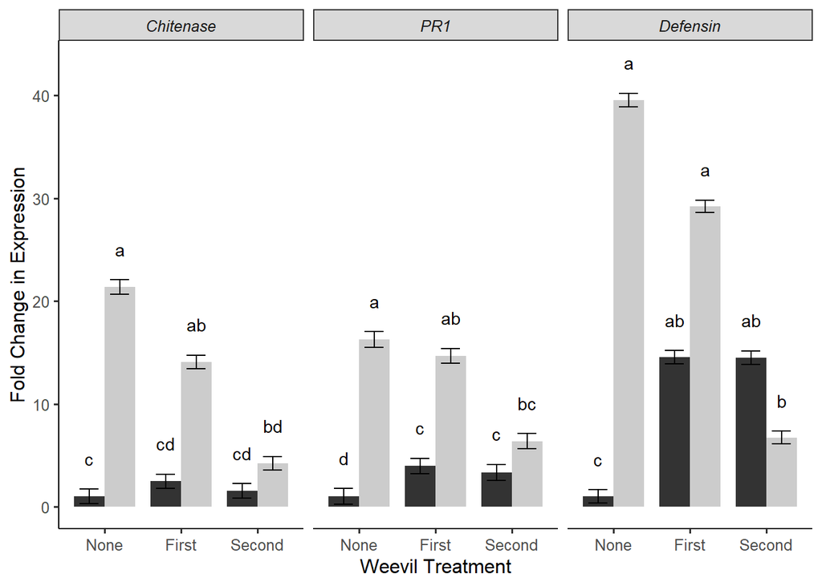

```r
labels.R1 <- c(Chitenase = "Chitenase", PR1 = "PR1", defensin = "Defensin")

r1.fig <- ggplot(R1.table, aes(x = factor(Weevil.Timing,
                                          levels = c("None", "First", "Second")),
                               y = emmean,
                               fill = factor(Aphid.Type,
                                             levels = c("Sham", "Infective")))) +
  geom_bar(stat = "identity", width = 0.8, position = "dodge") +
  geom_errorbar(aes(ymin = emmean - (SE), ymax = emmean + (SE)),
                position=position_dodge(0.8), width = 0.5) +
  theme_bw(base_size = 12) +
  theme(panel.border = element_blank(), panel.grid.major = element_blank(),
        panel.grid.minor = element_blank(),
        axis.line = element_line(colour = "black")) +
  labs(y = "Fold Change in Expression", x = "Weevil Treatment") +
  labs(fill = "Aphid Type") +
  scale_fill_grey() +
  theme(axis.line.x = element_line(color = "black", size = 0.5),
        axis.line.y = element_line(color = "black", size = 0.5)) +
  theme(legend.position = "none") +
  geom_text(aes(x = Weevil.Timing, y = (emmean+SE+3), label = .group),
            position = position_dodge(width = 0.8)) +
  facet_wrap( ~ Gene, labeller=labeller(Gene = labels.R1)) +
  theme(strip.text = element_text(face = "italic"))

r1.fig
```

### Building figure R2

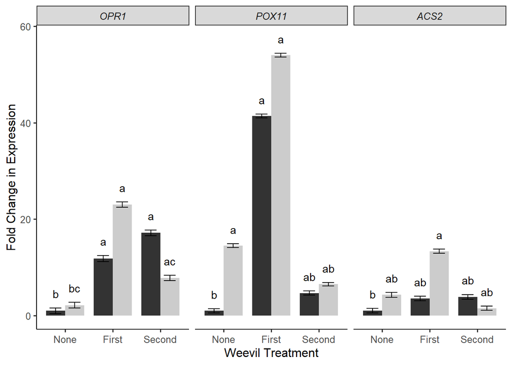

```r
R2.table <- filter(final.table,
                   Gene == "ACS2" | Gene == "OPR1" | Gene == "PsOX.11")
labels.R2 <- c(ACS2 = "ACS2", OPR1 = "OPR1", PsOX.11 = "POX11")

r2.fig <- ggplot(R2.table, aes(x = factor(Weevil.Timing,
                                          levels = c("None","First","Second")),
                               y = emmean,
                               fill = factor(Aphid.Type,
                                             levels = c("Sham", "Infective")))) +
  geom_bar(stat = "identity", width = 0.8, position = "dodge") +
  geom_errorbar(aes(ymin = emmean - (SE), ymax = emmean + (SE)),
                position = position_dodge(0.8), width = 0.5) +
  theme_bw(base_size = 12) +
  theme(panel.border = element_blank(), panel.grid.major = element_blank(),
        panel.grid.minor = element_blank(),
        axis.line = element_line(colour = "black")) +
  labs(y = "Fold Change in Expression", x = "Weevil Treatment") +
  labs(fill = "Aphid Type") +
  scale_fill_grey() +
  theme(axis.line.x = element_line(color = "black", size = 0.5),
        axis.line.y = element_line(color = "black", size = 0.5)) +
  theme(legend.position = "none") +
  geom_text(aes(x = Weevil.Timing, y = (emmean+SE+3), label = .group),
            position = position_dodge(width = 0.8)) +
  facet_wrap( ~ Gene, labeller = labeller(Gene = labels.R2)) +
  theme(strip.text = element_text(face = "italic"))

r2.fig
```

### Building figure R3

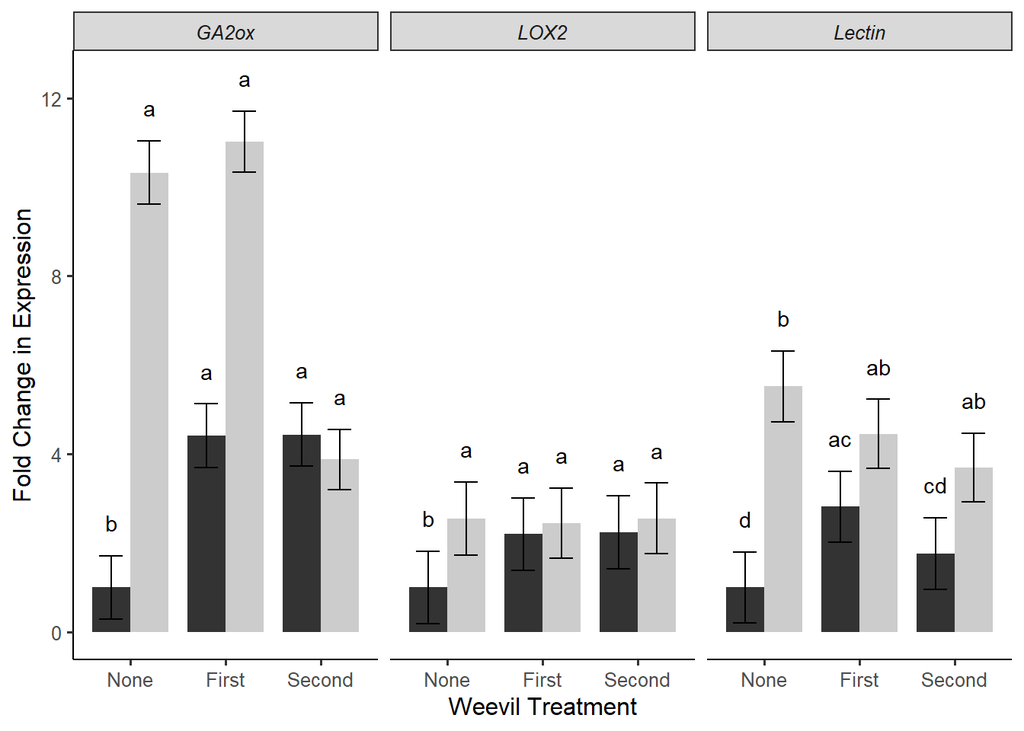

```r
R3.table <- filter(final.table,
                   Gene == "GA" | Gene == "lectin" | Gene == "LOX.2")
labels.R3 <- c(GA = "GA2ox", lectin = "Lectin", LOX.2 = "LOX2")

r3.fig <- ggplot(R3.table, aes(x = factor(Weevil.Timing,
                                          levels = c("None","First","Second")),
                               y = emmean,
                               fill = factor(Aphid.Type,
                                             levels = c("Sham", "Infective")))) +
  geom_bar(stat = "identity", width = 0.8, position = "dodge") +
  geom_errorbar(aes(ymin = emmean - (SE), ymax = emmean + (SE)),
                position = position_dodge(0.8), width = 0.5) +
  theme_bw(base_size = 12) +
  theme(panel.border = element_blank(), panel.grid.major = element_blank(),
        panel.grid.minor = element_blank(),
        axis.line = element_line(colour = "black")) +
  labs(y = "Fold Change in Expression", x = "Weevil Treatment") +
  labs(fill="Aphid Type") +
  scale_fill_grey() +
  theme(legend.position = "none") +
  theme(axis.line.x = element_line(color = "black", size = 0.5),
        axis.line.y = element_line(color = "black", size = 0.5)) +
  geom_text(aes(x = Weevil.Timing, y = (emmean + SE + 0.75), label = .group),
            position = position_dodge(width = 0.8)) +
  facet_wrap( ~ Gene, labeller = labeller(Gene = labels.R3)) +
  theme(strip.text = element_text(face = "italic"))

r3.fig
```

### Building figure R4

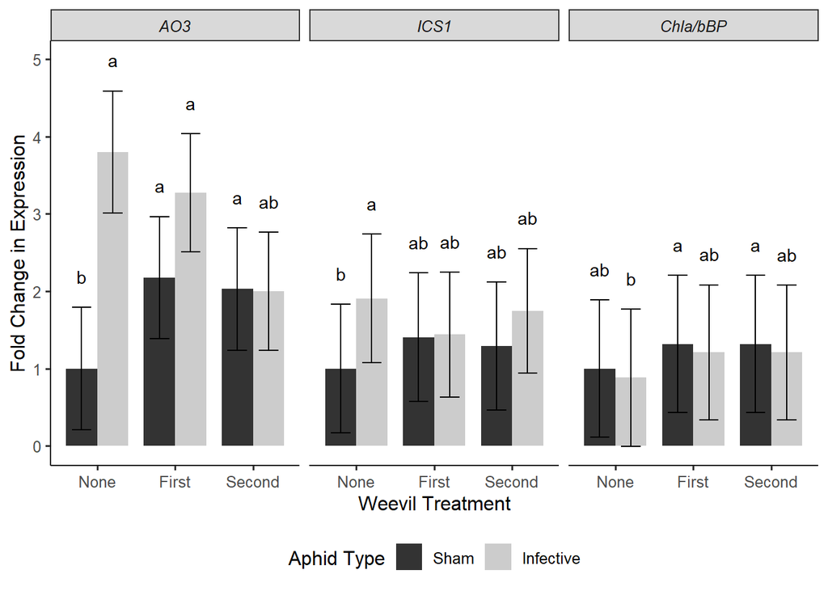

```r
R4.table <- filter(final.table,
                   Gene == "ICS1" | Gene == "ChlAbBp" | Gene == "AOX.3")
labels.R4 <- c(ICS1 = "ICS1", ChlAbBp = "Chla/bBP", AOX.3 = "AO3")

r4.fig <- ggplot(R4.table, aes(x = factor(Weevil.Timing,
                                          levels = c("None","First","Second")),
                               y = emmean,
                               fill = factor(Aphid.Type,
                                             levels = c("Sham", "Infective")))) +
  geom_bar(stat = "identity", width = 0.8, position = "dodge") +
  geom_errorbar(aes(ymin = emmean - (SE), ymax = emmean + (SE)),
                position = position_dodge(0.8), width = 0.5) +
  theme_bw(base_size = 12) +
  theme(panel.border = element_blank(), panel.grid.major = element_blank(),
        panel.grid.minor = element_blank(),
        axis.line = element_line(colour = "black")) +
  labs(y = "Fold Change in Expression", x = "Weevil Treatment") +
  labs(fill = "Aphid Type") +
  scale_fill_grey() +
  theme(legend.position = "bottom") +
  theme(axis.line.x = element_line(color = "black", size = 0.5),
        axis.line.y = element_line(color = "black", size = 0.5)) +
  geom_text(aes(x = Weevil.Timing, y = (emmean + SE + 0.4), label = .group),
            position = position_dodge(width = 0.8)) +
  facet_wrap( ~ Gene, labeller = labeller(Gene = labels.R4)) +
  theme(strip.text = element_text(face = "italic"))

r4.fig
```

Arrange into one large panel using ggpubr package.

[figure not shown]

```r
figure.r.all <- ggarrange(r1.fig, r2.fig, r3.fig, r4.fig,
                          labels = c("", "", "", ""),
                          ncol = 1, nrow = 4)
figure.r.all
```

## Part 3: Viral Titer

Infective aphids with PEMV were placed on pea plants. Tissue was collected at 4 days and 10 days. PEMV is an RNA virus, so ddct can be calculated for viral coat protein that should be replicating during infection. Cited as Basu et. al 2019/2020 in prep, but a separate paper from the MANOVA data.

### Data for PEMV transcript accumulation

```r
titer.dat <- read.csv("../data/pemv titer.csv", header = TRUE)
```

### 10 DPI Model

PEMV titer 10dpi, relative amount of viral titer, this is ten days post infection.

Exclude day four observations

```r
titer.ten <- subset(titer.dat, DPI != "Four")
str(titer.ten)
```

```
## 'data.frame':    36 obs. of  8 variables:
##  $ DPI              : Factor w/ 2 levels "Four","Ten": 2 2 2 2 2 2 2 2 2 2 ...
##  $ Treatment        : Factor w/ 4 levels "Autoclave soil",..: 1 1 1 1 1 1 1 1 1 2 ...
##  $ Biological.Sample: int  1 1 1 2 2 2 3 3 3 1 ...
##  $ Technical.Sample : int  1 2 3 1 2 3 1 2 3 1 ...
##  $ PEMVCQ           : num  18.5 18.4 18.6 20.6 21.2 ...
##  $ BTCQ             : num  25.4 26 25.2 27 26.9 ...
##  $ DeltaCQ          : num  -6.93 -7.64 -6.65 -6.44 -5.7 ...
##  $ ControlDeltaCQ   : num  -7.48 -7.48 -7.48 -7.48 -7.48 ...
```

10-day duration GLM

```r
c.ten.glm <- glm(DeltaCQ ~ Treatment, data = titer.ten)
Anova(c.ten.glm)
```

```
## Analysis of Deviance Table (Type II tests)
##
## Response: DeltaCQ
##           LR Chisq Df Pr(>Chisq)
## Treatment   47.417  3  2.834e-10 ***
## ---
## Signif. codes:  0 '***' 0.001 '**' 0.01 '*' 0.05 '.' 0.1 ' ' 1
```

```r
dct <- as.data.frame(cld(emmeans(c.ten.glm, ~ Treatment), sort = FALSE))
```

Group together

```r
dct$.group = gsub(" ", "", dct$.group)
```

Delta ct for 10.dpi

```r
dct$Delta.CT <- 2^(-dct$emmean)
dct$upper.SEM <- 2^(-(dct$emmean - pre.log$SE))
```

[output not shown]

```r
dct$lower.SEM <- 2^(-(dct$emmean + pre.log$SE))
```

[output not shown]

```r
dct$tukey <- as.factor(dct$.group)
```

### Building 10 DPI Fig

```r
raw.dct <- ggplot(dct, aes(x = Treatment, y = Delta.CT)) +
  geom_bar(stat = "identity", width = 0.5, position = "dodge") +
  geom_errorbar(aes(ymin = lower.SEM, ymax = upper.SEM),
                position = position_dodge(0.5), width = 0.2) +
  theme_bw(base_size = 12) +
  theme(panel.border = element_blank(),
        panel.grid.major = element_blank(),
        panel.grid.minor = element_blank(),
        axis.line = element_line(colour = "black")) +
  labs(y = "Relative Viral Titer (10 DPI)") +
  scale_x_discrete(labels = c("Autoclave", "Rhizobia", "Nitrogen","Control")) +
  theme(axis.line.x = element_line(color = "black", size = 0.5),
        axis.line.y = element_line(color = "black", size = 0.5),
        axis.title.x = element_blank()) +
  geom_text(aes(x = Treatment, y = upper.SEM + 10, label = .group),
            position = position_dodge(width = 0.8))

raw.dct
```

[output not shown]

[output not shown]

### 4 DPI Model

```r
titer.four <- subset(titer.dat, DPI == "Four")
c.four.glm <- glm(DeltaCQ ~ Treatment, data=titer.four)
Anova(c.four.glm)
```

```
## Analysis of Deviance Table (Type II tests)
##
## Response: DeltaCQ
##           LR Chisq Df Pr(>Chisq)
## Treatment   43.445  3  1.979e-09 ***
## ---
## Signif. codes:  0 '***' 0.001 '**' 0.01 '*' 0.05 '.' 0.1 ' ' 1
```

```r
dct.four <- as.data.frame(cld(emmeans(c.four.glm, ~ Treatment), sort=FALSE))
dct.four
```

```
##            Treatment    emmean        SE  df asymp.LCL asymp.UCL .group
## 1     Autoclave soil -6.731393 0.2196805 Inf -7.161958 -6.300827    1
## 2 Autoclave.Rhizobia -5.837737 0.2196805 Inf -6.268303 -5.407172     2
## 3   Control.Nitrogen -7.676247 0.2196805 Inf -8.106813 -7.245682      3
## 4        Control.NoA -7.484360 0.2196805 Inf -7.914926 -7.053794    1 3
```

Fix group labels so posthoc test looks nice

```r
dct.four$.group=gsub(" ", "", dct.four$.group)
dct.four
```

```
##            Treatment    emmean        SE  df asymp.LCL asymp.UCL .group
## 1     Autoclave soil -6.731393 0.2196805 Inf -7.161958 -6.300827      1
## 2 Autoclave.Rhizobia -5.837737 0.2196805 Inf -6.268303 -5.407172      2
## 3   Control.Nitrogen -7.676247 0.2196805 Inf -8.106813 -7.245682      3
## 4        Control.NoA -7.484360 0.2196805 Inf -7.914926 -7.053794     13
```

Delta ct for 4dpi

```r
dct.four$Delta.CT <- 2^(-dct.four$emmean)
dct.four$upper.SEM <- 2^(-(dct.four$emmean-pre.log$SE))
```

[output not shown]

```r
dct.four$lower.SEM <- 2^(-(dct.four$emmean+pre.log$SE))
```

[output not shown]

```r
dct.four$tukey <- as.factor(dct.four$.group)
```

4 DPI model

```r
raw.dct.four <- ggplot(dct.four, aes(x = Treatment, y = Delta.CT)) +
  geom_bar(stat = "identity", width = 0.5, position = "dodge") +
  geom_errorbar(aes(ymin = lower.SEM, ymax = upper.SEM),
                position = position_dodge(0.5), width = 0.2) +
  theme_bw(base_size = 12) +
  theme(panel.border = element_blank(),
        panel.grid.major = element_blank(),
        panel.grid.minor = element_blank(),
        axis.line = element_line(colour = "black")) +
  labs(y = "Relative Viral Titer (4 DPI)") +
  scale_x_discrete(labels = c("Autoclave", "Rhizobia", "Nitrogen","Control")) +
  theme(axis.line.x = element_line(color = "black", size = 0.5),
        axis.line.y = element_line(color = "black", size = 0.5),
        axis.title.x = element_blank()) +
  geom_text(aes(x = Treatment, y = upper.SEM + 10, label = .group),
            position = position_dodge(width = 0.8))

raw.dct.four
```

[output not shown]

[output not shown]

### 10 days DDct

Estimate for control delta cq for treatment is -7.4831. This uses control.noa as the baseline so its relative to 1 (control levels). Test is with 10 days post infection.

```r
titer.ten$dd.ct <- titer.ten$DeltaCQ - titer.ten$ControlDeltaCQ

ten.glm <- glm(dd.ct ~ Treatment, data=titer.ten)
summary(ten.glm)
```

```
##
## Call:
## glm(formula = dd.ct ~ Treatment, data = titer.ten)
##
## Deviance Residuals:
##     Min       1Q   Median       3Q      Max
## -1.4385  -0.5309   0.1475   0.5221   1.2735
##
## Coefficients:
##                             Estimate Std. Error t value Pr(>|t|)
## (Intercept)                   0.6855     0.2489   2.754  0.00963 **
## TreatmentAutoclave.Rhizobia   1.5716     0.3520   4.465 9.34e-05 ***
## TreatmentControl.Nitrogen    -0.2929     0.3520  -0.832  0.41147
## TreatmentControl.NoA         -0.6855     0.3520  -1.947  0.06032 .
## ---
## Signif. codes:  0 '***' 0.001 '**' 0.01 '*' 0.05 '.' 0.1 ' ' 1
##
## (Dispersion parameter for gaussian family taken to be 0.5576017)
##
##     Null deviance: 44.283  on 35  degrees of freedom
## Residual deviance: 17.843  on 32  degrees of freedom
## AIC: 86.895
##
## Number of Fisher Scoring iterations: 2
```

```r
pre.log <- as.data.frame(cld(emmeans(ten.glm, ~ Treatment), sort=FALSE))
pre.log
```

```
##            Treatment        emmean        SE  df   asymp.LCL asymp.UCL
## 1     Autoclave soil  6.854557e-01 0.2489091 Inf  0.19760286 1.1733086
## 2 Autoclave.Rhizobia  2.257088e+00 0.2489091 Inf  1.76923509 2.7449408
## 3   Control.Nitrogen  3.925135e-01 0.2489091 Inf -0.09533938 0.8803664
## 4        Control.NoA -2.452111e-05 0.2489091 Inf -0.48787739 0.4878284
##   .group
## 1     1
## 2      2
## 3     1
## 4     1
```

```r
pre.log$Delta.Delta.CT <- 2^(-pre.log$emmean)
pre.log$upper.SEM <- 2^(-(pre.log$emmean-pre.log$SE))
pre.log$lower.SEM <- 2^(-(pre.log$emmean+pre.log$SE))

pre.log$tukey <- as.factor(pre.log$.group)

pre.log
```

```
##            Treatment        emmean        SE  df   asymp.LCL asymp.UCL
## 1     Autoclave soil  6.854557e-01 0.2489091 Inf  0.19760286 1.1733086
## 2 Autoclave.Rhizobia  2.257088e+00 0.2489091 Inf  1.76923509 2.7449408
## 3   Control.Nitrogen  3.925135e-01 0.2489091 Inf -0.09533938 0.8803664
## 4        Control.NoA -2.452111e-05 0.2489091 Inf -0.48787739 0.4878284
##   .group Delta.Delta.CT upper.SEM lower.SEM tukey
## 1     1       0.6218094 0.7389012 0.5232728    1
## 2      2      0.2091938 0.2485867 0.1760434     2
## 3     1       0.7618012 0.9052547 0.6410805    1
## 4     1       1.0000170 1.1883284 0.8415468    1
```

Figure:

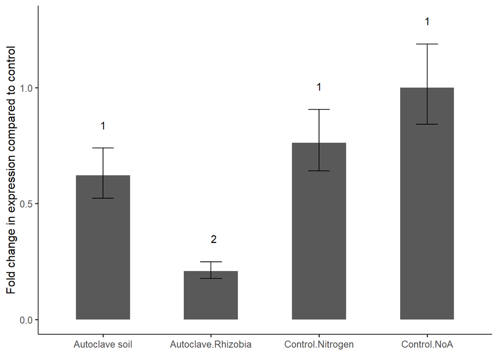

```r
ten.titer.fig <- ggplot(pre.log, aes(x = Treatment, y = Delta.Delta.CT)) +
  geom_bar(stat = "identity", width = 0.5, position = "dodge") +
  geom_errorbar(aes(ymin = lower.SEM, ymax = upper.SEM),
                position = position_dodge(0.5), width = 0.2) +
  theme_bw(base_size = 12) +
  theme(panel.border = element_blank(),
        panel.grid.major = element_blank(),
        panel.grid.minor = element_blank(),
        axis.line = element_line(colour = "black")) +
  labs(y = "Fold change in expression compared to control") +
  theme(axis.line.x = element_line(color = "black", size = 0.5),
        axis.line.y = element_line(color = "black", size = 0.5),
        axis.title.x = element_blank()) +
  geom_text(aes(x = Treatment, y = upper.SEM + 0.1, label = tukey),
            position = position_dodge(width = 0.8))

ten.titer.fig
```